# Lecture 9: Aggregation

Kelly and Gallego

Suprisingly often, we want to split a dataset into chunks and then ask about some property of each chunk. For example, how many flights landed at an airport on Tuesdays vs. Wednesdays? How do people in Arkansas think about climate change vs. people in Oregon? What’s the average age of people in Nigeria vs. Sudan? Etc.

In Excel, you would maybe do this by creating sub-spreadsheets for each site/location/etc you were interested in, and work on each separately. Or you would select some cells for some calculations, and put the results in a different column. Or you would write an `ifelse` command (but do you ever really do this in Excel?).

But in **R**, as we’ve already seen, there are easy and great ways of doing this. And really, this is what you’ve done several times with `for` loops.

But if we can avoid doing loops, that’s often a good idea.

Today, we’ll look at different aggregation techniques, in base **R** and tidyverse, both.

```r
ufo <- read.csv("../Data/UFOscrubbed.csv", as.is = T)

ufo$datetime <- as.Date(ufo$datetime, format = "%m/%d/%Y %H:%M")  #capture the correct date format

ufo$year <- format(ufo$datetime, format = "%Y")  #create a variable that just gives the year of the sighting
```

# Trends over time

Have UFO sightings increased/decreased over time?

- To answer this question, we want to aggregate sightings by year.

### In Base **R**

Here we will use the `aggregate` function, which does what it sounds like it would do.

```r
sightings.by.year <-                    #create a new object
    aggregate(ufo$datetime,             #use the aggregate function on a dataset
              by = list(ufo$year),      #give R one or more grouping variables in a list
              FUN = length)             #tell R what function you want to apply to each of the groups

#here, we are taking the sighting events (as reflected by date and time), grouping them by year, and just counting how many there were in each group (using the function `length`).

head(sightings.by.year)
```

```
##   Group.1 x
## 1    1906 1
## 2    1910 2
## 3    1916 1
## 4    1920 1
## 5    1925 1
## 6    1929 1
```

Note that by default, `aggregate` creates a column name for your grouping variables, and calls them “Group.1” , etc. You may want to rename them (as is done below). Now we can plot them.

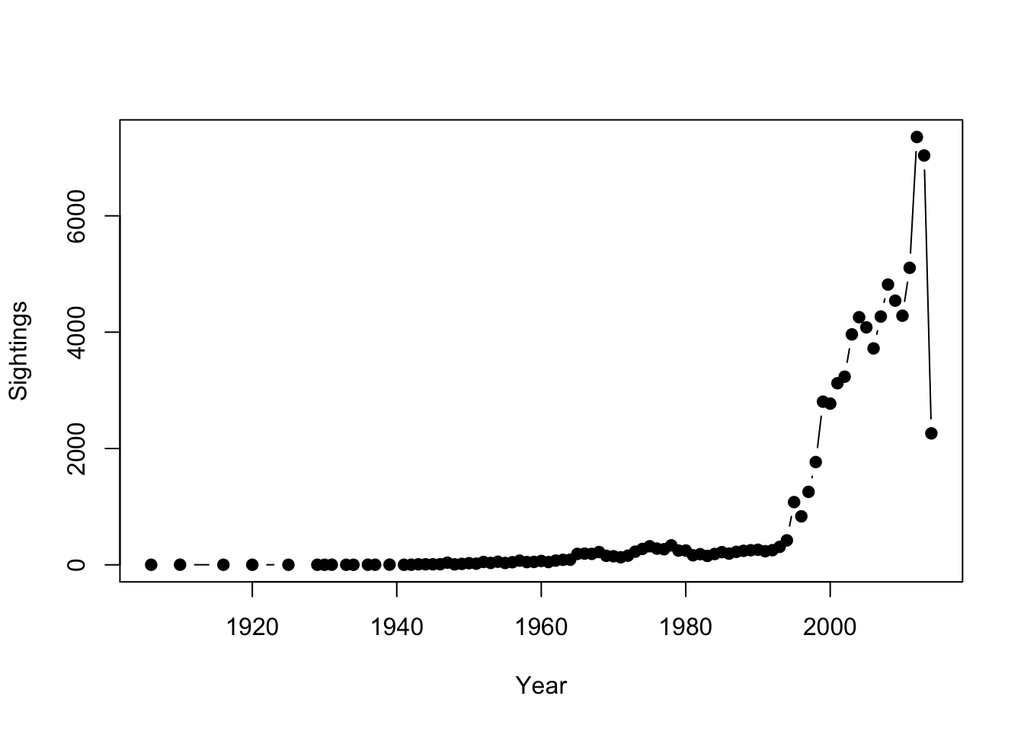

```r
names(sightings.by.year) <- c("Year", "Sightings")

plot(sightings.by.year, pch = 19, type = "b")
```

Wow. That’s quite a trend. Note that it’s not corrected for global population growth, but still…

OK – one more use of `aggregate`. Let’s break this down as observations per country per year.

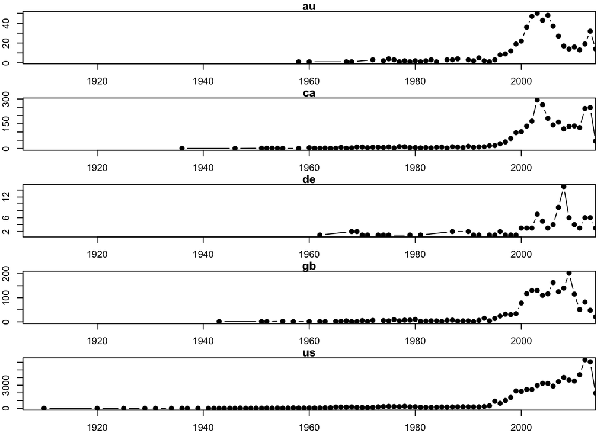

```r
sightings.by.country.year <-
      aggregate(ufo$datetime,             #use the aggregate function on a dataset
                by = list(ufo$year, ufo$country),      #give R one or more grouping variables in a list
                FUN = length)             #tell R what function you want to apply to each of the groups

names(sightings.by.country.year)<- c("Year", "Country", "Sightings")  #rename
sightings.by.country.year <- sightings.by.country.year[sightings.by.country.year$Country!="",] #filter to keep only those with a country listed

par(mfrow=c(5,1))
par(mar = c(2,2,1,1))
  for (i in unique(sightings.by.country.year$Country)){
    plot(Sightings~Year,
         data = sightings.by.country.year[sightings.by.country.year$Country == i,],
         xlim = c(1910,2010),
         pch = 19, type = "b",
         main = i)
  }
```

OK, cool. And note the y-axis: UFO sightings (or at least, reportings of them) are almost entirely an American phenomenon.

The point here is that you can apply any function you want (here, we used `length`, but it could have been anything) to different slices of your dataset. Very handy.